# A Hierarchical Model for Data-to-Text Generation

# Contents

1. Paper Review
   - Introduction
   - Data
   - Notation/General Overview
   - Hierarchical Encoding Model
   - Hierarchical Attention
   - Evaluation
   - Implementation Details
2. Code Review
   - Make_dataset.py
   - Preprocess.py
   - Train.py
   - Model
3. Model Structure
   - NMTModel(Encoder, Decoder))
   - Hierarchical Transformer Encoder
   - Hierarchical RNN Decoder(TBD)
   - Inference Stage(TBD)
4. Appendix
   - Basic
   - Information Extraction
   - Copy Mechanism
   - Beam Search
   - Classification Evaluation Metrics
   - Block Eyed Attention mask

# Paper Review

## Introduction

기존의 Data-to-text 모델들이 좋은 결과를 보여줬지만 2가지 단점이 존재

> 1. Linearization of the data-structure
>    - 데이터를 unique한 sequence로 표현하기 때문에 row 사이에서의 관계를 잃게됨
> 2. Arbitrary ordering of unordered collections in recurrent networks
>    - 대부분의 data-to-text structure는 encoder로 RNN(LSTM, GRU)을 사용하기 때문에 발생하는 한계점이 있음
>    - RNN계열의 방식은 input이 sequential하게 모델에 들어가야 하는데 이전 연구들에서 input이 임의의 순서(이미 데이터가 순서가 있는 데이터가 아님)로 들어가는 문제가 발생

해당 논문에서는 Transformer로 two-level architecture encoder를 사용했고, Decoder는 기존 모델들과 동일하게 구성

> 1. 레코드(record)를 기반으로 모든 entity를 encoding
> 2. Entity를 기반으로 모든 data-structure를 encoding
> 3. Transformer 모델을 사용해서 초기 포지셔닝에 상관없이 record/entity를 다른 모든 record/entity와 비교할 수 있게 되었음

## Data

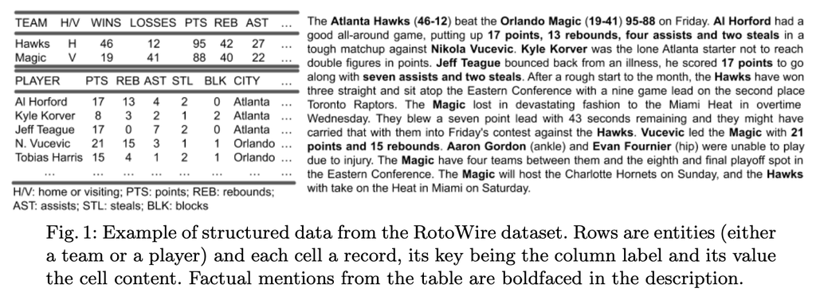

## Notation / General Overview

- Entity $(e_i)$
  - 순서가 없는 record인 $\{r_{(i,1)}, r_{(i,2)}, ..., r_{(i,J_{i})}\}$ 의 집합
  - 하나의 entity인 `Jeff Teague`는 `{(PTS,17), (REB,0) ...}` 의 record를 가짐
- Record
  - $(r_{i,j})$는 $(k_{i,j}, v_{i,j})$의 pair임
  - (PTS,17),`PTS`는 key, `17`은 value
- Data Structure ${s}$
  - 순서가 없는 entities $e_i$ 의 집합이고, $s:={e_1, e_2, ... , e_I}$ 로 표현
  - Data Structure 는 `(Hawks, Magic, Al Horford, Jeff Teague, ....)`
- Text Description
  - t번째 단어까지는 $y_{1:t}$로 표현. 전체 문장은 $y_{1:T}$ 로 표현
- Dataset $D$
  - (Data structure, description) pair의 collection
- Objective function  
  $ \begin{align} \underset{\theta}{argmax\ \mathcal{L} (\theta)} = \underset{\theta}{argmax} \sum_{(s,y)\in D} log P(\hat{y}=y|s; \theta) \end{align} $
- Decoder
  - 기존 모델들과 동일하게 Copy-Mechanism이 적용된 two-layers LSTM을 사용.
  - inference 단계에서는 Beam-Search를 사용

## Hierarchical Encoding Model

### Encoder Diagram

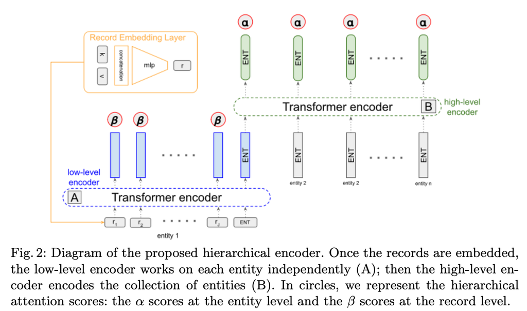

### First Layer

- 첫번째 레이어는 2개(key, value)의 $d$차원의 임베딩 행렬로 구성됨. ($\mathbf k_{i,j}\in \mathbf{R}^d, \mathbf v_{i,j}\in \mathbf{R}^d$)
- $r_{i,j}$ = $\text{ReLU}(\mathbf W_r[\mathbf k_{i,j} ; \mathbf v_{i,j}]+ \mathbf B_r)$ where $\mathbf W_r \in \mathbf{R}^{2dxd}$ and $\mathbf b_r \in \mathbf{R}^{d}$
- $\mathbf W_r$과 $\mathbf b_r$은 학습되는 파라미터

### Low-level encoder

동일 Entity에 속하는 record collection을 encoding하는 것이 목적. Transformer 사용

1. record embedding $r_{i,j}$를 이용해서 각각의 Entity를 encoding함
2. 각각의 $r_{i,j}$는 마지막 hidden representation인 ${\mathbf h_{i,j}}$를 학습하기 위해서 다른 record embedding과 비교됨
3. [ENT]라는 특별한 record도 추가를 한다. 이유는?
   - Entity별로 record에 따라 길이가 달라질 수 있으므로 고정된 사이즈의 representation vector$(\mathbf h_i)$로 집계될 수 있도록 해줌

### High-level encoder

전체 Entity 집합을 encoding하는 것이 목적. Transformer 사용

1. Entity representation인 $\mathbf h_i$를 이용해서 encoding을 함
2. Entity의 hidden state인 $\mathbf e_i$는 $\mathbf h_i$와 다른 $\mathbf h_i$를 비교하면서 계산됨
3. $\mathbf z$는 entity representations($\mathbf e_i$)들의 평균이고, decoder의 initialization으로 사용됨

## Hierarchical Attention

### Traditional Hierarchical Attention

Dynamic Context는 two step으로 계산된다고 가정한다. two step은 Entity에 먼저 관심을 가지고 그 후 해당 Entity에 속하는 record에 관심을 가지는 방식을 의미

1. **각각의 decoding step *t*에서**
2. 모델은 $e_i$에 대한 $\alpha_{i,t}$의 attention score(normalized)의 집합을 학습
3. $e_i$에 속하는 $r_{i,j}$에 대한 $\beta_{i,j,t}$의 attention score(normalized)의 집합을 학습

Entity는 record embedding의 가중평균으로 표현되고, 전체 Data Structure는 entity representaion의 가중 평균으로 표현된다.  
Dynamic context는 아래와 같이 계산된다.  
$ \begin{align} \mathbf c_t = \sum_{i=1}^{I}(\alpha_{i,t}(\sum_{j}\beta_{i,j,t} \mathbf r_{i,j})) \,\, \,\,\text{where}\,\,\, \alpha_{i,t} \,\,{\propto} \,\,exp(\mathbf d_t \mathbf W_\alpha \mathbf e_i) \,\,\,\text{and}\,\,\, \beta_{i,j,t} \,\,{\propto} \,\,exp(\mathbf d_t \mathbf W_\beta \mathbf h_{i,j}) \end{align} $

- $\mathbf d_t$는 decoder step *t*에서의 hidden state를 의미
- $\mathbf W_{\alpha} \in \mathbf R^{dxd}$와 $\mathbf W_{\beta} \in \mathbf R^{dxd}$ 이고 학습 파라미터
- $\sum_{i}\alpha_{i,t} = 1 \text{ for all } i \in \{1,...,I \}$
- $\sum_{j}\beta_{i,j,t} = 1 $

### Key-guided Hierarchical Attention

Entity가 선택되기만 하면 description의 내용을 결정하는 가장 중요한 요인은 record의 type일 것이다라는 직관을 따르는 변형 모델  
예를 들어, 어떤 선수에 대해서 말을 결정하면, value는 고려하지 않고 score에 대해서 보통 언급을 하게 되는 것에서 차용한 아이디어이다. 라고 합니다.

- 여기서는 full record representation $h_{i,j}$ 를 사용하지 않고 *key*의 embedding을 단독을 사용한다.
- $\hat{\beta}_{i,j,t}\,\, {\propto} \,\,exp(\mathbf d_t \mathbf W_{\alpha 2} \mathbf k_{i,j})$

## Evaluation

1. **Bilingual Evaluation Understudy(BLEU)**
   - Text Generation 에서 주로 쓰이는 평가 지표
   - 실제 문장과 예측된 문장의 ngram 비교를 통해 계산
   - [BLEU - 쉽게 설명해 놓은 블로그](https://donghwa-kim.github.io/BLEU.html)
2. **Information Extraction-oriented metrics(IE)**
   - 데이터(테이블)에서의 값을 문장에 반영하는 정도를 측정
   - Information Extraction은 처음에 Gold Summary 데이터 바탕으로 모델이 학습
   - 위에서 학습된 모델을 통해 예측 문장을 모델에 넣어서 나오는 결과가 Entity-value pair
   - Information Extraction Input : `Isaiah Thomas led the team in scoring, totaling 23 points ...`
   - Information Extraction Output : `(Isaiah Thomas, 23, PTS)`
     > 1. Content Selection(CS)
     >    - 모델이 생성한 문서가 실제 문서를 얼마나 반영했는지 레코드(record) 관점에서 평가하는 지표
     >    - 예측된 문장에서 추출된 unique한 relation의 precision과 recall를 측정
     > 2. Relation Generation(RG)
     >    - 모델이 실제 기록을 포함하는 텍스트를 얼마나 잘 생성해냈는지를 평가하는 지표
     >    - 예측된 문장에서 추출된 unique한 relation의 precision과 absolute number를 측정
     > 3. Content Ordering(CO)
     >    - 모델이 레코드(record)의 순서를 얼마나 맞췄는지를 평가하는 지표
     >    - 실제 문장에서 추출된 sequences of records 와 예측 문장에서 추출된 sequences of records 사이의 [normalized Damerau-Levenshtein Distance](https://hsp1116.tistory.com/41)를 이용해서 측정

## Implementation Details

- low-level, high-level encoder = two-layers multi-head self-attention with two heads.
- key's embedding size = 20
- value's embedding size 300
- hidden layers of the Transformer encoders = 300
- dropout rate = 0.5
- batch size = 64
- optimizer = Adam
- learning rate = 0.001 , 10K 스텝마다 절반
- beam size = 5

# Code Review

## Make_dataset.py

raw data는 json 형태로 되어 있으며 크게 home_name, vis_name으로 나누어지고 각각에는 box_score안에는 경기기록 데이터가 포함되어 있음

```
make_dataset.py main()
 ├── make_dataset.py box_preprocess()         # raw data를 받아서 엔터티 형태의 데이터로 전처리. 학습에 사용될 source 데이터를 만드는 과정
 │      ├── make_dataset.py get_player_idxs() # 홈팀 선수와 어웨이팀 선수의 idx 번호를 부여. 홈팀 선수에게는 13-25번, 어웨이팀 선수에게는 0-12번까지의 인덱스를 부여한다.
 │      ├── make_dataset.py _build_home()     # box_preprocess 함수에서는 각 선수에 대한 데이터를 전처리했다면, _build_home 함수는 팀에 대한 데이터를 전처리하는 함수이다.
 │      └── make_dataset.py _build_vis()      # _build_home과 동일하게 away팀을 처리하는 함수이다.
 └── make_dataset.py _clean_summary()         # 학습에서 사용되는 target 데이터 전처리 과정. 단순히 space 기준으로 tokenize를 진행한다. copy mechanism의 처리를 돕기 위해서 multi-words의 space( )를 underscore(_)로 변경한다.
```

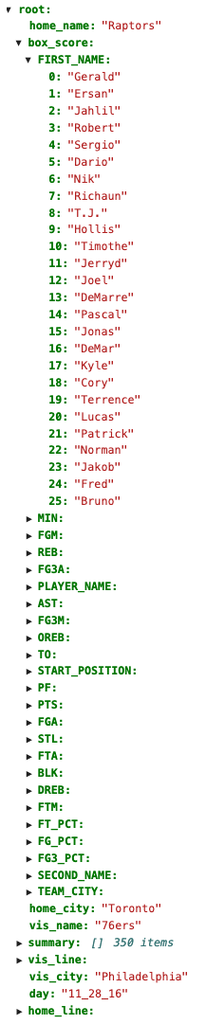

```python
#### 하나의 Entity가 최대 24개의 지표를 가지게 수동으로 정의
ENT_SIZE = 24

bs_keys = ['START_POSITION', 'MIN', 'PTS', 'FGM', 'FGA', 'FG_PCT', 'FG3M',
           'FG3A', 'FG3_PCT', 'FTM', 'FTA', 'FT_PCT', 'OREB', 'DREB', 'REB',
           'AST', 'TO', 'STL', 'BLK', 'PF', 'FIRST_NAME', 'SECOND_NAME']

ls_keys = ['PTS_QTR1', 'PTS_QTR2', 'PTS_QTR3', 'PTS_QTR4', 'PTS', 'FG_PCT',
           'FG3_PCT', 'FT_PCT', 'REB', 'AST', 'TOV', 'WINS', 'LOSSES', 'CITY',
           'NAME']

ls_keys = [f'TEAM-{key}' for key in ls_keys]
```

#### make_dataset을 통해 전처리된 결과 데이터

```python
# Gerald Henderson, 어웨이 팀 선수의 데이터
result[:24]
```

```
['<ent>￨<ent>',
 'F￨START_POSITION',
 '17￨MIN',
 '0￨PTS',
 '0￨FGM',
 '7￨FGA',
 '0￨FG_PCT',
 '0￨FG3M',
 '2￨FG3A',
 '0￨FG3_PCT',
 '0￨FTM',
 '0￨FTA',
 '0￨FT_PCT',
 '0￨OREB',
 '1￨DREB',
 '1￨REB',
 '2￨AST',
 '1￨TO',
 '0￨STL',
 '0￨BLK',
 '1￨PF',
 'Gerald￨FIRST_NAME',
 'Henderson￨SECOND_NAME',
 'no￨IS_HOME']
```

```python
# 어웨이 팀인 Philadelphia 76ers의 데이터
result[-24:]
```

```
['<ent>￨<ent>',
 '26￨TEAM-PTS_QTR1',
 '23￨TEAM-PTS_QTR2',
 '22￨TEAM-PTS_QTR3',
 '24￨TEAM-PTS_QTR4',
 '95￨TEAM-PTS',
 '42￨TEAM-FG_PCT',
 '41￨TEAM-FG3_PCT',
 '69￨TEAM-FT_PCT',
 '38￨TEAM-REB',
 '27￨TEAM-AST',
 '14￨TEAM-TOV',
 '4￨TEAM-WINS',
 '14￨TEAM-LOSSES',
 'Philadelphia￨TEAM-CITY',
 '76ers￨TEAM-NAME',
 'no￨IS_HOME',
 'Monday￨DAY_OF_WEEK',
 '<blank>￨<blank>',
 '<blank>￨<blank>',
 '<blank>￨<blank>',
 '<blank>￨<blank>',
 '<blank>￨<blank>',
 '<blank>￨<blank>']
```

## preprocess.py

make_dataset 단계에서 전처리된 데이터로 학습에 input으로 사용할 train, valid, test 데이터를 생성하는 단계. 이 단계에서 token 전체에 대한 vocabuluary도 생성됨

### Preprocess Flow

```
preprocess.py main()
 └── onmt/bin/preprocess.py main()
       └── onmt/bin/preprocess.py preprocess()
             ├── count_features()
             └── inputter.get_fields()
```

## Train.py

### Train Flow

```
train.py main()
 └── onmt/bin/train.py main()
      └── onmt/bin/train.py train()
           ├── onmt/inputters/inputter.py build_dataset_iter
           └── train_single.py single_main() (main())
                ├── configure_process()
                ├── init_logger()
                ├── torch.load()  -> load checkpoint if exist
                ├── load_old_vocab
                ├── build_model() -> Described at next cell
                ├── onmt/utils/optimizers.py Optimizer.from_opt()
                ├── onmt/models/model_saver.py build_model_saver()
                ├── onmt/trainer.py build_trainer() -> build_loss_compute
                ├── onmt/inputters/inputter.py build_dataset_iter() -> train_iter
                ├── onmt/inputters/inputter.py build_dataset_iter() -> valid_iter
                └── onmt/trainer.py train()
                     ├── _accum_batches -> _accum_count(), input batch를 생성함
                     ├── _gradient_accumulation() -> input을 model에 통과시켜서 loss를 구하고 파라미터를 갱신함
                     └── 이후 validation은 train 비슷하게 진행됨
```

## Model

### Model build flow

```
onmt/model_builder.py build_model()
 └── onmt/model_builder.py build_base_model()
       ├── onmt/model_builder.py build_embeddings()  --> call twice for src_emb & tgt_emb
       │    └── onmt/modules/table_embeddings.py TableEmbeddings
       ├── build_encoder()  --> encoder dispatcher function
       │    └── onmt/encoders/ str2enc[enc_type].from_opt()  --> HierarchicalTransformerEncoder
       ├── build_decoder()  --> decoder dispatcher function
       │    └── onmt/decoders/ str2dec[dec_type].from_opt()  --> HierarchicalRNNDecoder
       ├── onmt/models/model.py onmt.models.NMTModel()
       ├── onmt/modules/copy_generator.py CopyGenerator
       └── model.generator, model.to
```

### Encoder, Decoder 종류

```
encoder_type: htransformer  # Type of encoder [rnn|brnn|transformer|htransformer|cnn]
decoder_type: hrnn  # Type of decoder [rnn|transformer|cnn|hrnn]

str2enc = {"rnn": RNNEncoder, "brnn": RNNEncoder, "cnn": CNNEncoder,
           "transformer": TransformerEncoder, "img": ImageEncoder,
           "audio": AudioEncoder, "mean": MeanEncoder, "htransformer": HierarchicalTransformerEncoder}

str2dec = {"rnn": StdRNNDecoder, "ifrnn": InputFeedRNNDecoder,
           "cnn": CNNDecoder, "transformer": TransformerDecoder,
           "hrnn": HierarchicalRNNDecoder}
```

# Model Structure

## NMTModel(Encoder, Decoder)

크게 Encoder, Decoder 두 부분으로 구성되어 있다.

- Encoder : HierarchicalTrasformerEncoder
- Decoder : HierarchicalRNNDecoder
- generator : CopyGenerator

## HierarchicalTransformerEncoder

크게 `Embedding`, `Unit Encoder`, `Chunk Encoder` 세 부분으로 구성되어 있다.

- Unit Encoder는 논문에서 Low Level Encoder를 뜻함
- Chunk Encoder는 논문에서 High Level Encoder를 뜻함

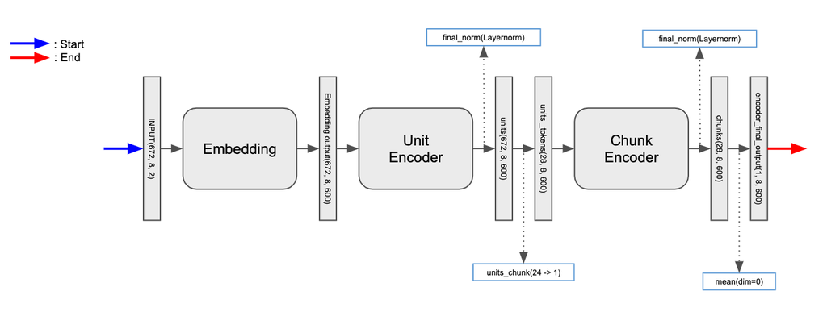

### 1. embeddings

1. value_embeddings : (479->600)은 전체 vocab 사이즈가 479이고 600차원으로 임베딩한다.
2. pos_embeddings : (42->20)은 전체 pos(key) vocab 사이즈가 42이고 20차원으로 임베딩한다.
3. concat : value_embedding과 pos_embedding 결과가 concat된다.
4. linear : 620차원의 벡터를 600차원으로 임베딩한다.
- *Config*
  - *600 : word_vec_size*
  - *20 : feat_vec_size*
  - *MLP : linear(620->600)*

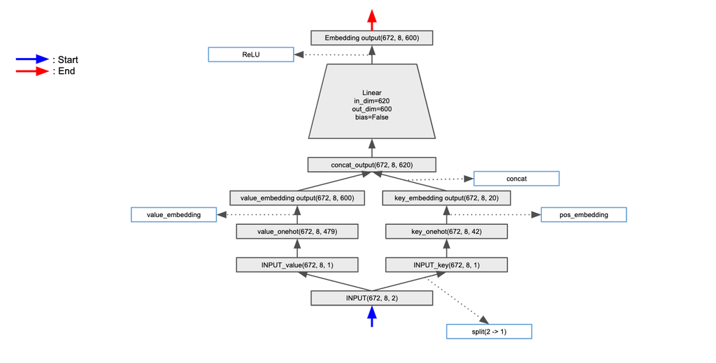

### 2. Unit Encoder

논문에는 low level encoder, high level encoder로 나눠서 설명되어 있지만 실제 구현에는 아주 동일한 구조의 transformer 모델로 구성되어 있고 이는 세 부분으로 구성되어 있다.

1. TransformerEncoderLayer * num_layer
   - Self-Attention
     - Attention Mask : 모든 Record들이 서로 attention을 계산하는 것이 아니고 하나의 Entity에 속하는 record끼리의 attention을 계산하기 위해서 block-eye mask 를 이용(1x672x672)
     - [GLU(Gated Linear Unit)](https://towardsdatascience.com/how-to-build-a-gated-convolutional-neural-network-gcnn-for-natural-language-processing-nlp-5ba3ee730bfb) : 활성 함수 대신 사용
   - Residual Connection
     - 레이어가 깊어질수록 수렴에 효과가 있음
   - FeedForward
     - 각각의 부분에 대해서 Attention output을 얻어낸 결과를 골고루 섞어주는 역할을 한다.
2. Final Normalization
   - 결과값에 대한 Layer normalization 진행

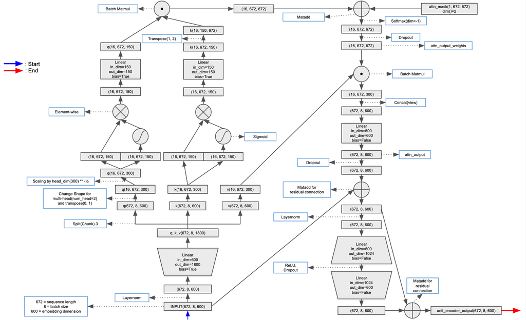

### 3. Chunk Encoder

- Unit Encoder의 output (Entity Representation, $h_i$)를 input 으로 받아서 하나의 경기 데이터를 대표하는 representation vector를 만들어짐
- Unit Encoder와 구조 동일
- Attention Mask의 종류만 다름
  - Unit Encoder와는 다르게 Entity들이 서로 attention을 계산해야 하기 때문에 16x28x28 크기의 마스크를 이용

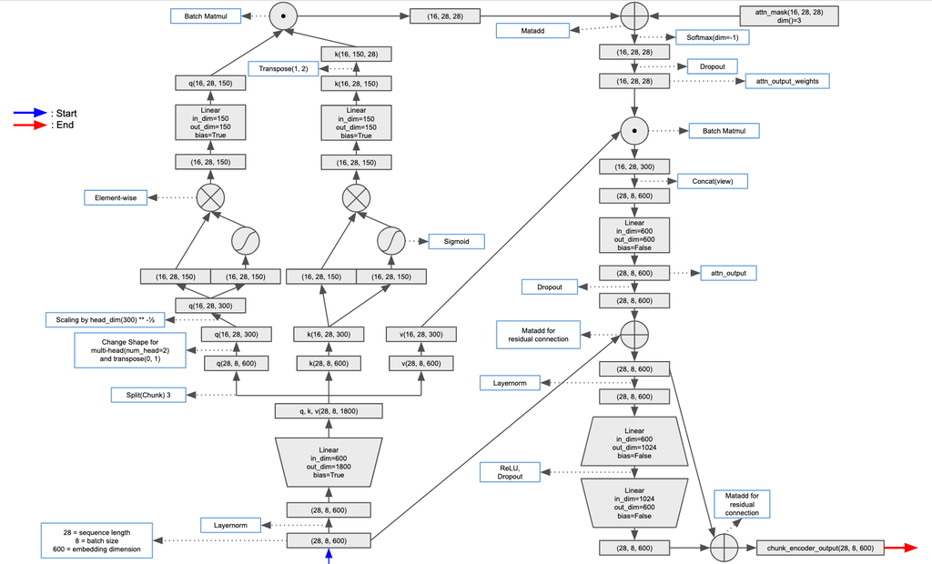

# Appendix

## Basic

1. RNN / LSTM
   - https://ratsgo.github.io/natural%20language%20processing/2017/03/09/rnnlstm/
   - https://www.slideshare.net/DonghyeonKim7/recurrent-neural-network-rnn
2. Seq2Seq
   - [논문링크](https://arxiv.org/pdf/1508.04025.pdf)
   - https://lovit.github.io/machine%20learning/2019/03/17/attention_in_nlp/
   - http://jalammar.github.io/visualizing-neural-machine-translation-mechanics-of-seq2seq-models-with-attention/
3. Transformer
   - http://nlp.seas.harvard.edu/2018/04/03/attention.html
   - http://jalammar.github.io/illustrated-transformer/

## Information Extraction

기존 NMT 모델에서는 BLEU를 많이 사용되지만 BLEU는 문장을 얼마나 잘 따라했냐 같은 fluency한 부분에 초점이 맞춰진 지표이다. Data-to-text 모델에서는 생성된 문장의 유창함보다는 얼마나 정확한 정보가 전달되었는지가 중요하기 때문에 Information Extraction을 이용한 새로운 평가 방법을 사용한다. Data-to-text 관련 논문은 모델을 평가하기 위해서 BLEU뿐만 아니라 Information Extraction도 모델 평가에 사용했다.

모델 정리

1. 문장에서 생성 될 수 있는 모든 후보 entity와 value의 모든 조합 $(r.e, r.m)$를 고려
2. 위의 pair를 가지고 $r.t$를 예측, multi-class classification 문제
3. 1, 2단계를 통해 문장에서 $(r.e, r.m, r.t)$를 추출할 수 있음

정답 문장의 (데이터, 문장) pair를 이용해 multi-class classification 모델을 학습한다. 그리고 예측 문장을에서 $(r.e, r.m)$ pair를 추출 한 뒤 해당 모델에 넣으면 $r.t$를 예측하여 $(r.e, r.m, r.t)$ pair를 생성할 수 있다. 따라서 Evaluation 단계에서는 정답 문장에서 추출된 $(r.e, r.m., r.t)$ pair와 예측 문장에서 추출된 $(r.e, r.m, r.t)$ pair를 기존의 classification 평가 지표처럼 사용할 수 있게 된다. 이를 이용해 CS, RG, CO metrics를 계산하여 평가하게 된다.

## Copy Mechanism

대부분의 NLP 문제에서 rare, unknown 등장 문제는 모델 성능 저하에 많은 영향을 준다. copy mechanism은 이러한 문제를 해결하기 위한 제안된 방법으로 [Pointing the unknown word](https://arxiv.org/pdf/1603.08148.pdf) 논문에서는 **Pointer Softmax** 라는 방법을 사용했다. 각각의 time-step에서 target 단어를 예측하기 위해 크게 2단계로 학습한다. 첫번째는 다음 예측 단어를 vocab dictionary에서 가져올 지 context에서 copy할 지에 대해 판단한다. 그리고 context에서 copy를 한다면 어느 위치에 있는 단어를 pointing할 지에 대해서도 학습하게 된다.

### The Pointer Softmax

- 모델 두 가지 학습 point
  1. 각 스텝에서 pointing이 요구되는지 아닌지 판단할 수 있어야함
  2. copy할 단어의 location을 pointing 가능해야함
- Basic Components of the Pointer Softmax
  1. Location softmax
     - source text에서 target으로 copy될 단어의 위치를 예상
     - 일종의 pointer network
     - 각각의 output dimension이 context seqeunce의 word의 location과 일치
  2. Shortlist softmax
     - 일반적인 softmax output layer와 동일
  3. Switching network
     - MLP with sigmoid output function
     - context sequence와 이전 hidden state를 input으로 하고 binary variable인 $z_t$를 output으로 함
     - $z_t=1$이면 shortlist softmax를 사용하고 $z_t=0$이면 location softmax를 사용

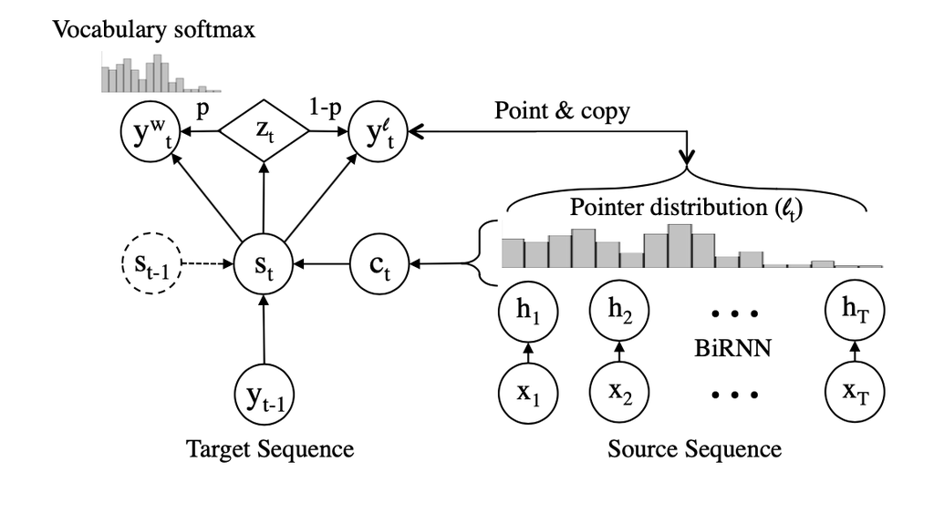

## Beam Search

Greedy Search Algorithm은 매우 쉽고 간편하지만 최적의 해를 보장하지 않는다. 최적의 해에 좀 더 가까워지기 위해 약간의 트릭을 첨가하는데 k개의 후보를 더 추적하는 방법이 Beam Search이다. 이때 k를 Beam size라고 한다.  
Beam Search를 사용하면 더 넓은 경로에 대해 탐색을 수행하므로 더 나은 성능을 보장합니다. 하지만 Beam size만큼 더 많은 추론을 수행해야 하므로 속도저하가 발생한다. 일반적으로 Beam size가 10 이상일 경우 성능이 더 나아지지 않으므로 10 이하로 설정해 사용한다.

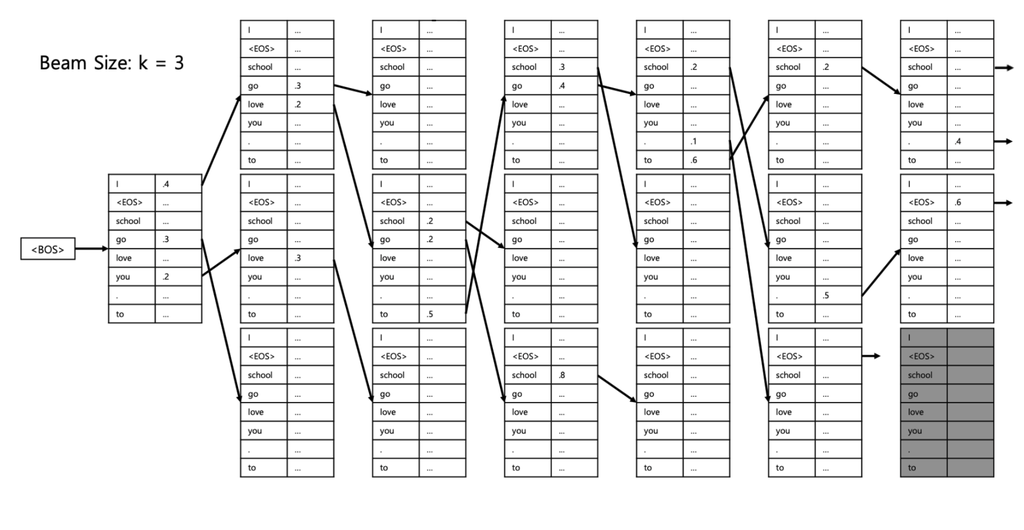

- 현재 time-step에서 최고 누적 확률을 가진 인덱스의 단어 k개를 뽑은 뒤 다음 time-step에 대해 k번 추론을 수행
- 총 k x |V| 개의 softmax 결과 중 다시 최고 누적 확률 k개를 뽑아 다음 time-step으로 전달. |V|는 어휘 사전의 크기. 예를 들어 k=3, |V|=30000이면, 총 90000개의 누적 확률 중 값이 가장 높은 3개를 선택
- 추론 중 EOS가 나올 경우 다른 추론 중에서 k만큼 선택하고, k개 이상의 EOS가 나오면 디코딩이 끝나고(Beam Search 종료) 누적확률 높은 순서대로 k개를 선택

여기서 중요한 점은 다음과 같습니다.

> 1. 누적 확률을 사용하여 최고 순위 k개를 뽑습니다. 이 때 보통 로그 확률을 사용하므로 **현재 time-step까지의 로그 확률에 대한 합**을 추적이 필요
> 2. 이전 time-step에서 뽑힌 k개에 대해 계산한 현재 time-step의 k개에 대해 **각각 k개를 뽑는 것이 아닌 것**에 주의

## Classification Evaluation Metrics

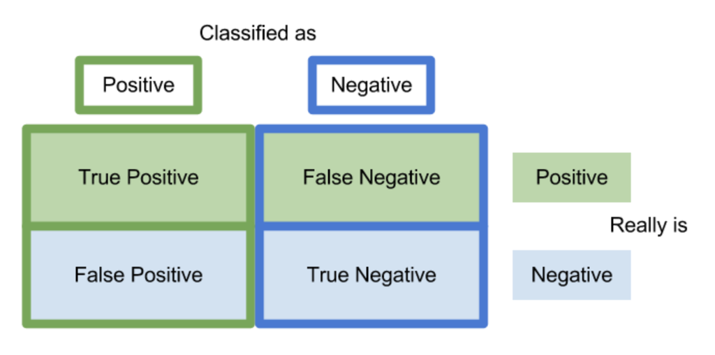

## Block Eyed Attention mask

- Unit Encoder의 attention_output_weights도 아래 매트릭스와 같은 672x672 형태
- Masking을 위한 Block Eyed Matrix는 아래와 같음. (이후 softmax 과정에서 값을 0에 가깝게 만들기 위해서 -inf 사용)
- attention_output_weights가 Block Eyed Matrix와 더해지면서 entity들 각각의 record끼리만 attention을 계산한 결과를 얻을 수 있음

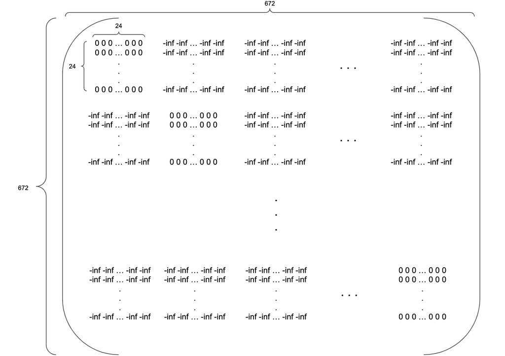